# Aside

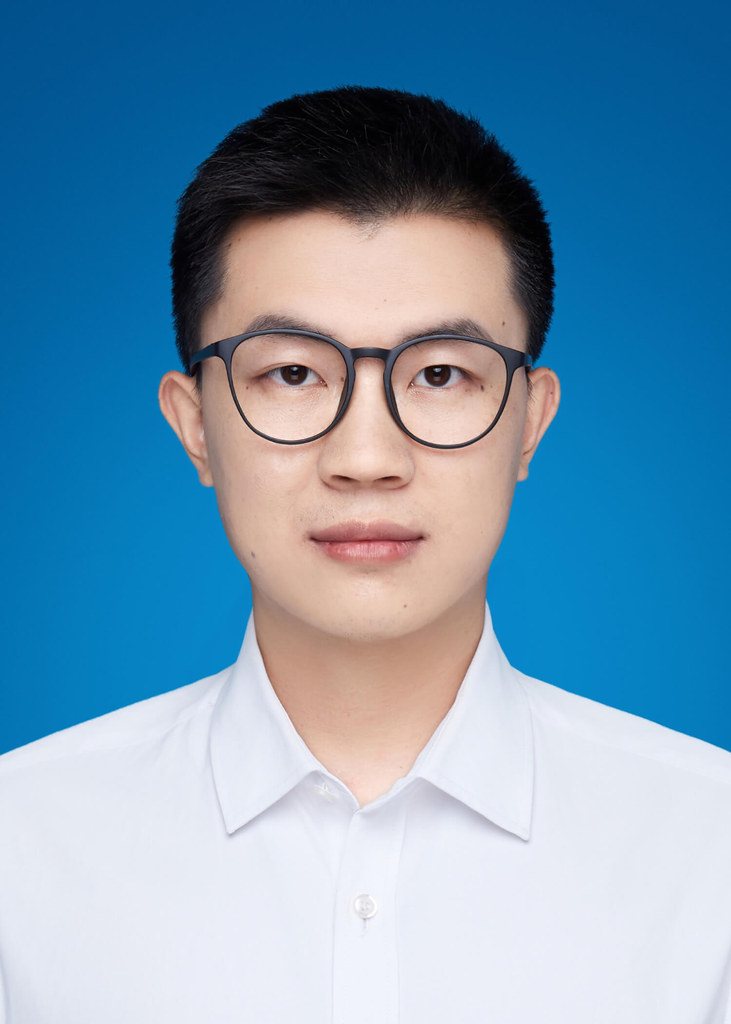

[Download a PDF of this CV](https://taoyan.netlify.app/pdf/CV.pdf)

## Contact

- tyan@zju.edu.cn
- [TaoYan](https://twitter.com/TaoYANLogos)
- github.com/YTLogos
- [taoyan.netlify.app](https://taoyan.netlify.app/)
- yt056410
- (86) 13372566428
- Citation = 864
- H-index = 14
- I10-index = 15

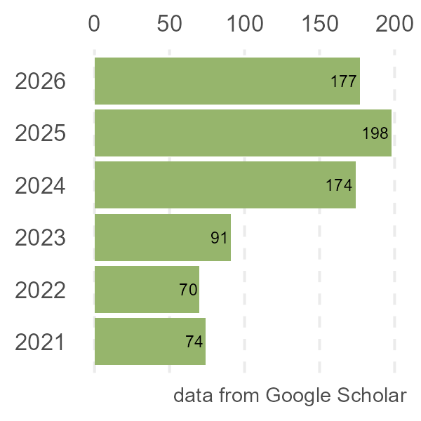

Last updated on 2026-09-21.

# Main

## Tao Yan(严涛)

Lecturer at College of Agronomy, Hunan Agricultural University (HUNAU), Changsha, China. My Ph.D research work covers a range of issues: Population Genetics Evolution and Ecotype Divergence Analysis of *Brassica napus*, Genome-wide Association Study (GWAS) of Agronomic Traits. Currently, I am interested in Transposable Elements Insertion Polymorphisms (TIPs) in Crop Population and genetic basis such as SV, CNV and TIPs etc. Now my research focus on Crop Stress and Improvement.

I am broadly interested in bioinformatics, data integration and visualization.

## Research Experience

### Lecturer

College of Agronomy

Hunan Agricultural University

present - 2021

## Education

### PhD., Crop Genetics and Breeding

Zhejiang University

Hangzhou, CN

2021 - 2016

- Thesis: Genomic polymorphism analysis and digital utilization of germplasm resources in rapeseed (*Brassica napus* L.)

### B.S., Crop Genetics and Breeding

Zhejiang University

Hangzhou, CN

2016 - 2012

## Scholarships & Awards

### 浙江大学优秀毕业生

Zhejiang University

Hangzhou, CN

2021 - 2020

### 浙江省优秀毕业生

Zhejiang University

Hangzhou, CN

### Model Student of Academic Records and Merit Student

Zhejiang University

Hangzhou, CN

2020 - 2019

### National Scholarship for Postgraduates

Zhejiang University

Hangzhou, CN

### Model Student of Academic Records and Merit Student

Zhejiang University

Hangzhou, CN

2018 - 2017

### Second-class Scholarship and Merit Student

Zhejiang University

Hangzhou, CN

2015 - 2014

### Third-class Scholarship and Merit Student

Zhejiang University

Hangzhou, CN

2014 - 2013

## Publications

### [Differentiation of genome-wide DNA methylation between japonica and indica rice](https://doi.org/10.1111/tpj.17218)

**The Plant Journal**. 2025, 121(2):e17218.

N/A

2025

- **Tao Yan**, Liuhui Kuang, Fei Gao, Jian Chen, Lin Li, Dezhi Wu
- **First author**
- Impact Factor = 6.25

### [BnaSNPDB: An interactive web portal for the efficient retrieval and analysis of SNPs among 1,007 rapeseed accessions](https://doi.org/10.1016/j.csbj.2020.09.031)

**Computational and Structural Biotechnology Journal**. 2020, 18:2766-2773.

N/A

2020

- **Yan, T.**, Wang, Q., Maodzeka, A., Wu, D., **Jiang, L.***
- **First author**
- Impact Factor = 7.409

### [BnaGVD: A genomic variation database of rapeseed (Brassica napus)](https://doi.org/10.1093/pcp/pcaa169)

**Plant and Cell Physiology**. 2021, 62(2):378–383.

N/A

2021

- **Yan, T.**, Yao, Y., Wu, D., **Jiang, L.***
- **First author**
- Impact Factor = 5.516

### [Genome-wide association study reveals new genes involved in leaf trichome formation in polyploid oilseed rape (Brassica napus L.)](https://doi.org/10.1111/pce.13694)

**Plant, Cell & Environment**. 2020, 43(3):675-691.

N/A

2020

- Xuan, L.<sup>#</sup>, **Yan, T.**<sup>#</sup>, Lu, L., Zhao, X., Wu, D., Hua, S., **Jiang, L.***
- **Co-first author**
- Impact Factor = 7.791

### [Transcriptomic Profiling of Cold Stress-Induced Differentially Expressed Genes in Seedling Stage of Indica Rice](https://doi.org/10.3390/plants12142675)

**Plants**. 2023, 12(14):2675.

N/A

2023

- **Tao Yan**, Meng Sun, Rui Su, Xiaozhong Wang, Xuedan Lu, Yunhua Xiao, Huabing Deng, Xiong Liu, Wenbang Tang, Guilian Zhang
- **First author**
- Impact Factor = 4.0

### [Transcriptome-wide m6A methylation and metabolomic analysis reveal regulatory networks in rice roots under manganese stress](https://doi.org/10.1016/j.envexpbot.2024.105906)

**Environmental and Experimental Botany**. 2024, 105906.

N/A

2024

- Tingting Su, Jian Chen, Xing Huo, Liuhui Kuang, **Tao Yan**, Fei Gao, Dezhi Wu
- Impact Factor = 4.5

### [Genomic and transcriptome analyses reveal potential contributors to erucic acid biosynthesis in seeds of rapeseed (Brassica napus)](https://doi.org/10.1007/s00122-024-04642-9)

**Theor Appl Genet**. 2024, 137(6):129.

N/A

- Shiqi Xu, Shan Chen, Jialing Cai, **Tao Yan**, Mengxin Tu, Ruisen Wang, Shuijin Hua, Lixi Jiang
- Impact Factor = 4.5

### [Multi-omics analysis reveals differential molecular responses to cadmium toxicity in rice root tip and mature zone](https://doi.org/10.1016/j.jhazmat.2023.132758)

**Journal of Hazardous Materials**. 2023, 462.

N/A

2023

- Liuhui Kuang, **Tao Yan**, Fei Gao, Wenbang Tang, Dezhi Wu
- Impact Factor = 12.2

### [Genome-wide association study reveals a patatin-like lipase relating to the reduction of seed oil content in Brassica napus](https://doi.org/10.1186/s12870-020-02774-w)

**BMC Plant Biology**. 2021, 21(6).

N/A

2021

- Haoyi Wang, Qian Wang, Haksong Pak, **Tao Yan**, Mingxun Chen, Xiaoyang Chen, Dezhi Wu and **Lixi Jiang***
- Impact Factor = 4.960

### [Prediction of heterosis in the recent rapeseed (Brassica napus) polyploid by pairing parental nucleotide sequences](https://doi.org/10.1371/journal.pgen.1009879)

**PLoS Genetics**. 2021, 17(11).

N/A

- Qian Wang,**Tao Yan**,Zhengbiao Long,Luna Yue Huang,Yang Zhu,Ying Xu,Xiaoyang Chen,Haksong Pak,Jiqiang Li,Dezhi Wu,Yang Xu ,Shuijin Hua ,**Lixi Jiang***
- Impact Factor = 5.917

### [Whole-genome resequencing of a world-wide collection of rapeseed accessions reveals genetic basis of their ecotype divergence](https://doi.org/10.1016/j.molp.2018.11.007)

**Molecular Plant** . 2019, 12(1):30-43.

N/A

2019

- Wu, D., Liang, Z., **Yan, T.**, Xu, Y., Xuan, L., Tang, J., Zhou, G., Lohwasser, U., Hua, S., Wang, H., Chen, X., Wang, Q., Zhu, L., Maodzeka, A., Hussain, N., Li, Z., Li, X., Shamsi, I.H., Jilani, G., Wu, L., Zheng, H., Zhang, G., Chalhoub, B., Shen, L., Yu, H., **Jiang, L.***
- Impact Factor = 16.357

### [Effect of high night temperature on storage lipids and transcriptome changes in developing seeds of oilseed rape](https://doi.org/10.1093/jxb/ery004)

**Journal of Experimental Botany**. 2018, 69(7):1721–1733.

N/A

2018

- Zhou, L., **Yan, T.**, Chen, X., Li, Z., Wu, D., Hua, S., **Jiang, L.***
- Impact Factor = 7.860

### [TRANSPARENT TESTA 4‐mediated flavonoids negatively affect embryonic fatty acid biosynthesis in Arabidopsis](https://doi.org/10.1111/pce.13402)

**Plant, Cell & Environment**. 2018, 41(12):2773-2790.

N/A

- Xuan, L., Zhang, C., **Yan, T.**, Wu, D., Hussain, N., Li, Z., Chen, M., Pan, J., **Jiang, L.***
- Impact Factor = 7.791

## Conference proceedings

### Construction and utilization of a core germplasm of Brassica napus

第一届全国作物学科博士生论坛, Oct 2020

Taiyuan, CN

2020

- 获取优秀奖

### GWAS reveals new genes involved in leaf trichome formation in polyploid oilseed rape (Brassica napus L.)

第十二届长三角作物学博士生论坛, Oct 2019

Yangzhou, CN

2019

- 获取优秀奖